# Irrigation monitoring

Thomas

March 2016

### Import and interpolate data

Import raster and vector data from GRASS GIS location  
Inversion models interpolated with optimized (cross-validated) regularized spline with tension (RST)

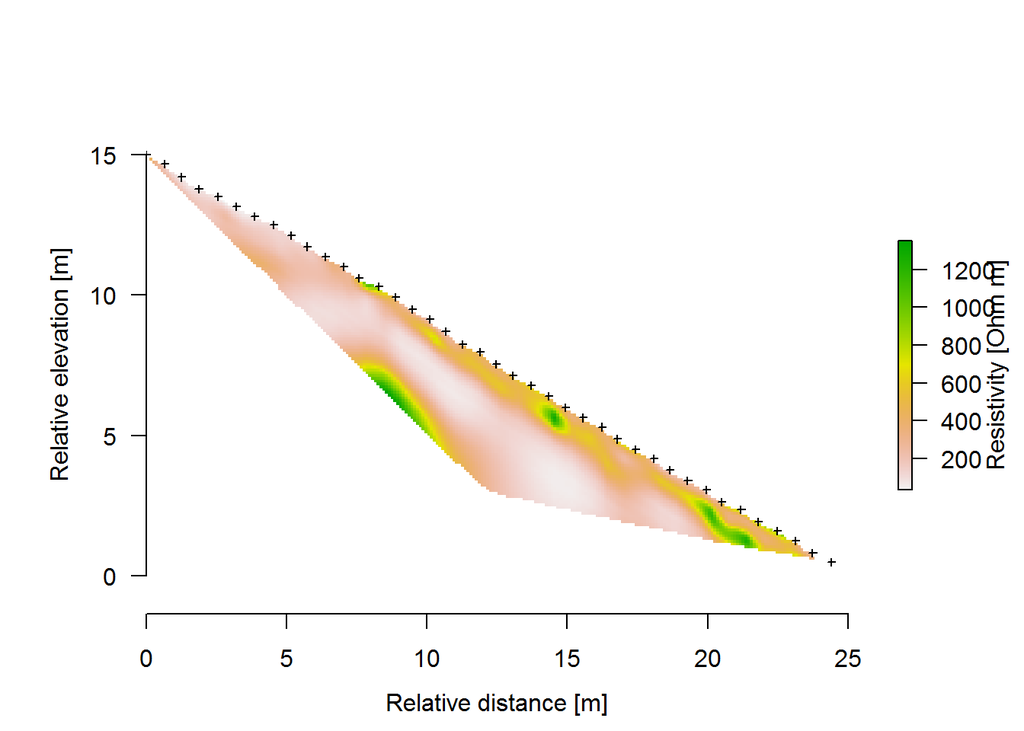

### Value range of first five datasets

First five measurements conducted before the beginning of irrigation experiment  
Range assumed to represent the repeatability and uncertainties of the measurements  
Generally higher uncertainties near the surface

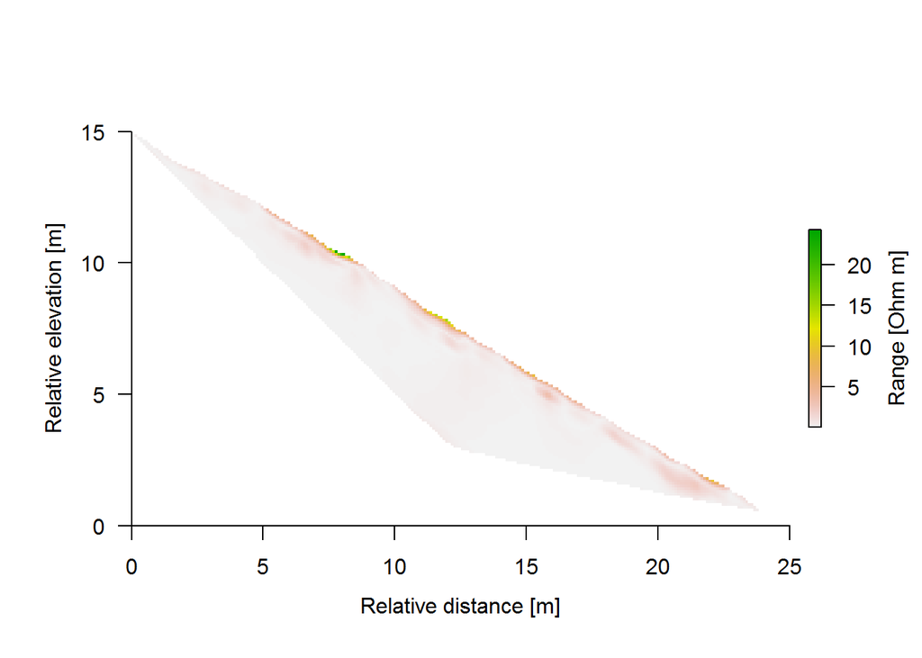

Relative deviation from mean

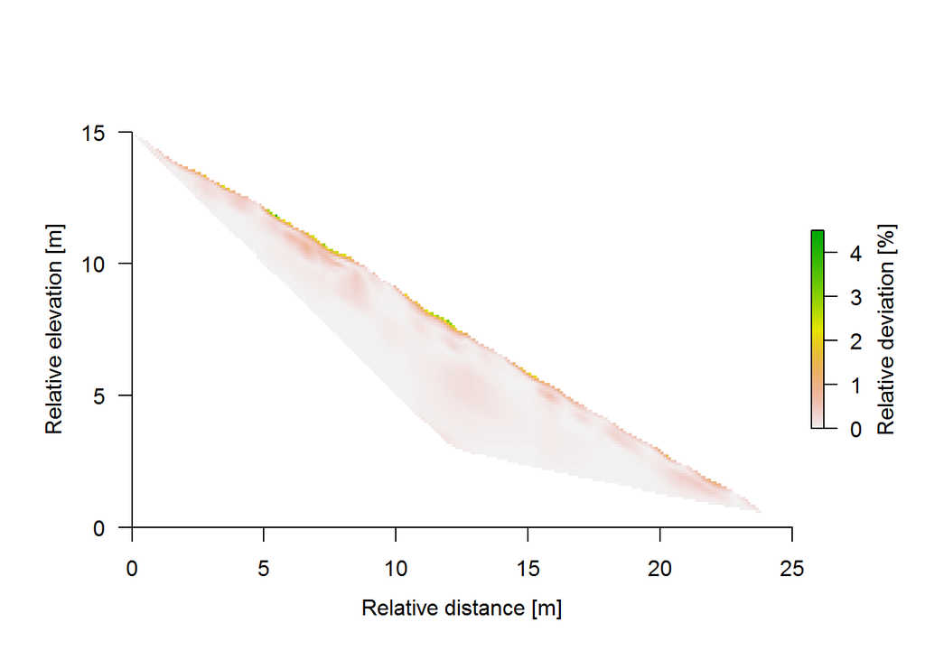

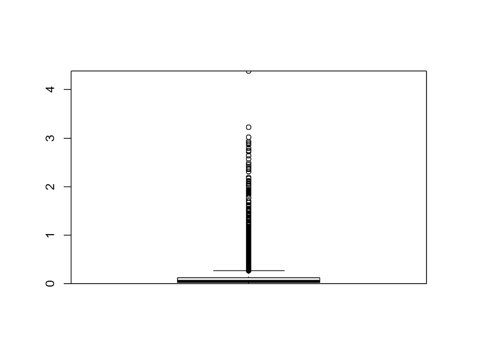

Mean deviation with depth (relative to mean of first five measurements)

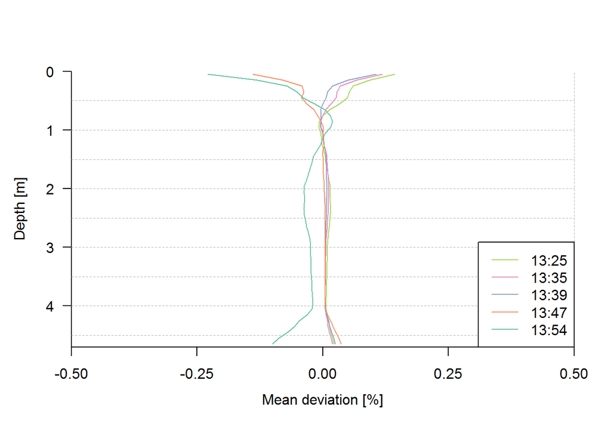

### Overall changes

Range of all datasets before tracer divided by reference (mean of first five measurements)  
Changes in the uppermost 1m due to irrigation  
Changes below due to artefacts (changing contrast due to irrigation)  
Water front did not reach bedrock (DCPT)

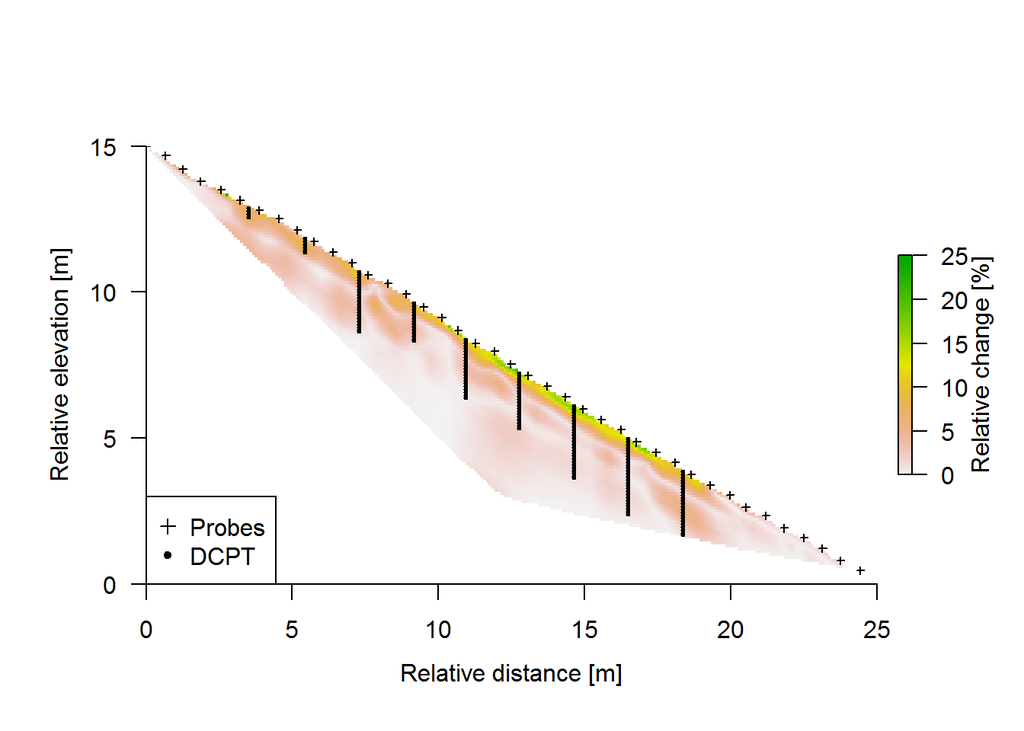

Mean overall changes with depth

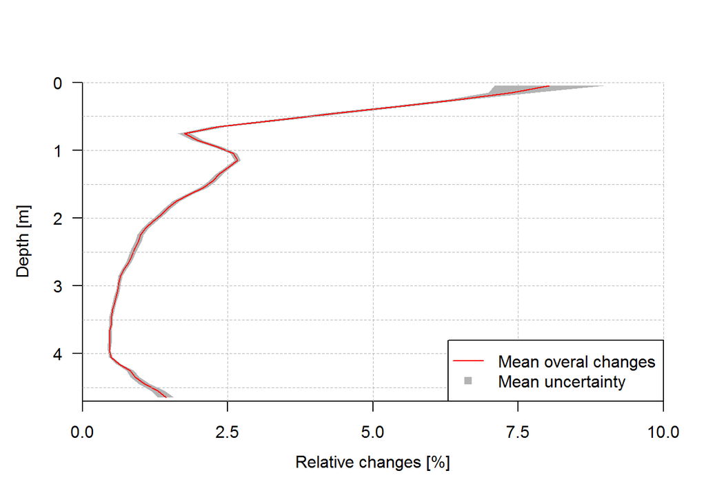

### Build depth mask

Restrict further analysis to upper 2m within irrigation plot (no bias from area outside)

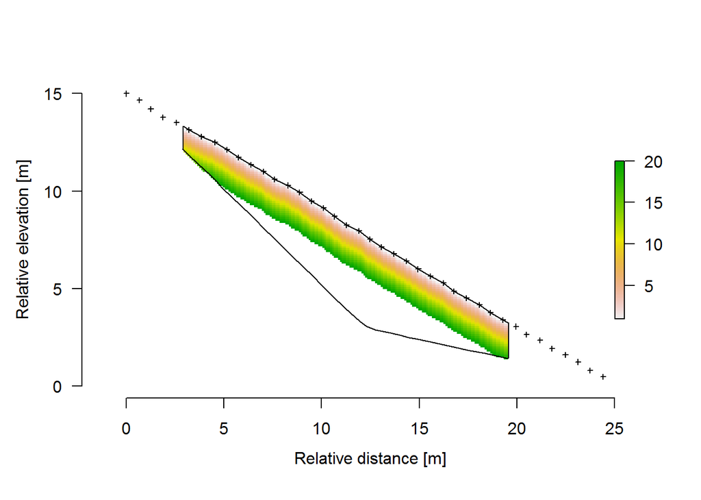

### Plot mean relative resistivity ratio with depth for each time step

Data restricted to uppermost 2m within irrigation plot (depth mask)  
Ratio to mean of first five measurements

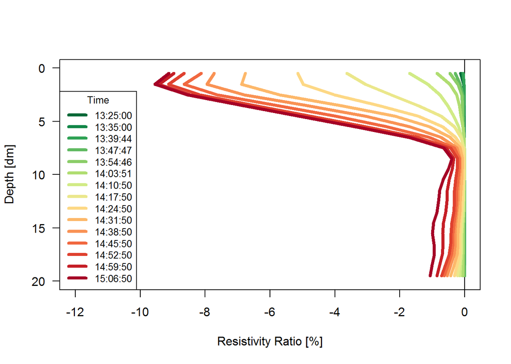

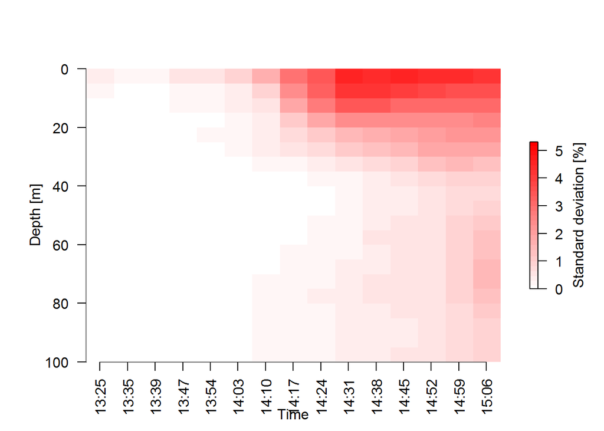

Mean resistivity ratio per depth over time

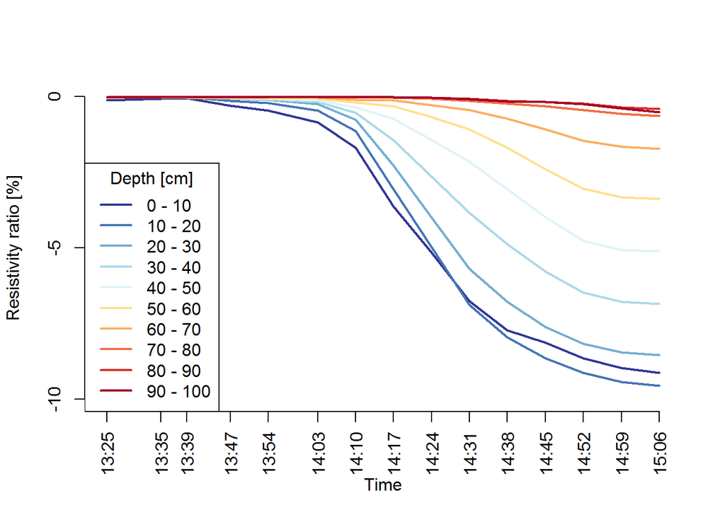

### Recorded TDR data

TDR at depth 40 did not record meaningful data

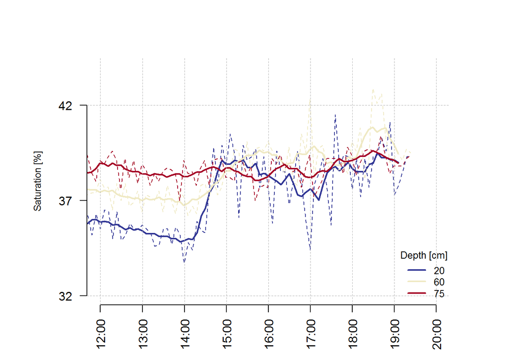

### Compare soil moisture and resistivity

…not necessary for further steps, but interesting…  
1. Fitting of a scaled logistic time-dependent model to variation of resistivity ratio in the depths corresponding to the TDR depths  
2. Extraction of the resistivity values corresponding to the time of TDR measurements  
3. Comparison of resistivity ratio and corresponding volumetric water content and fitting a linear model (poly, exp etc. does not yield better results…)

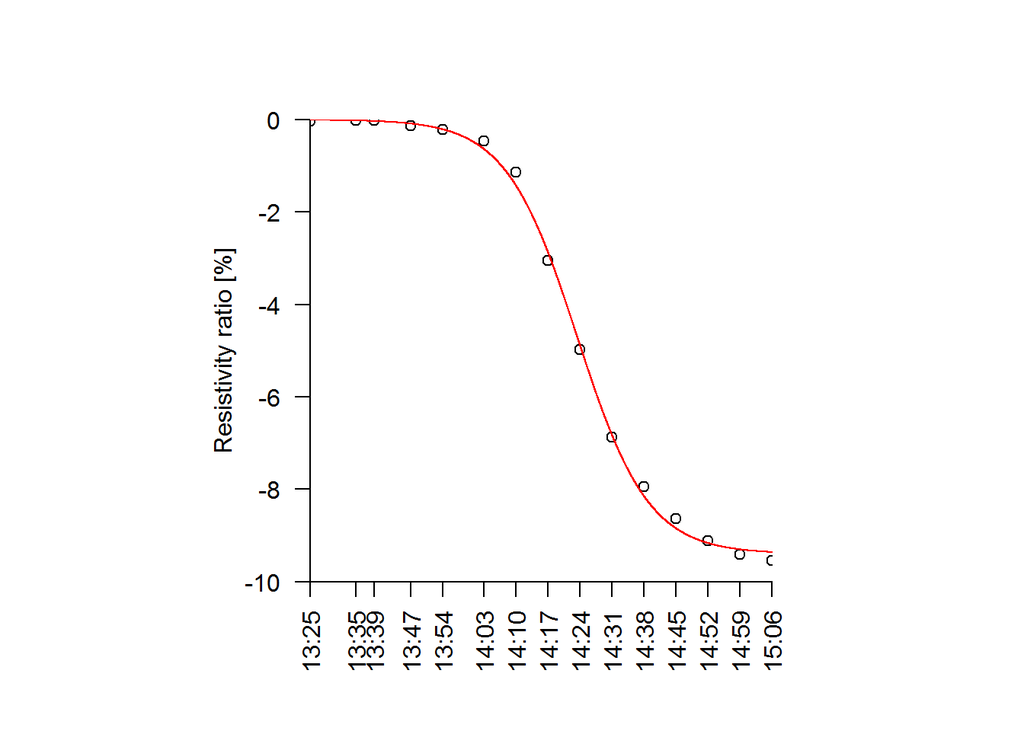

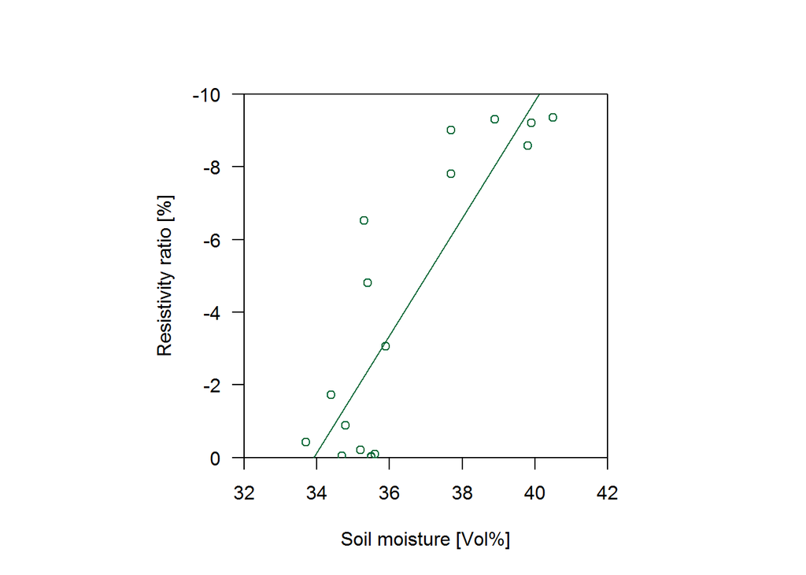

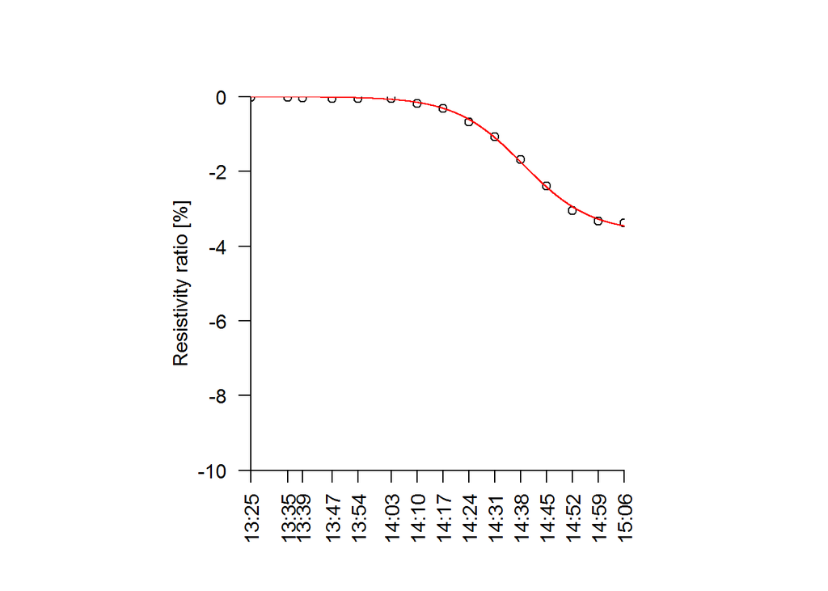

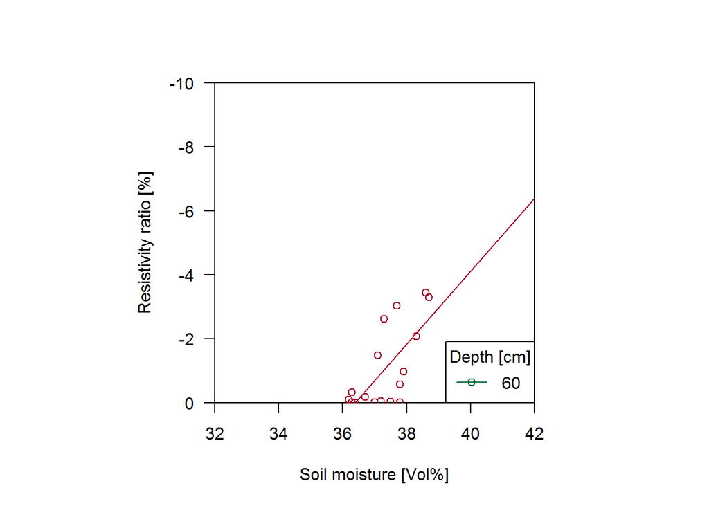

```
## [1] "R-squared: 0.489"
```

### Fit SWCC to data

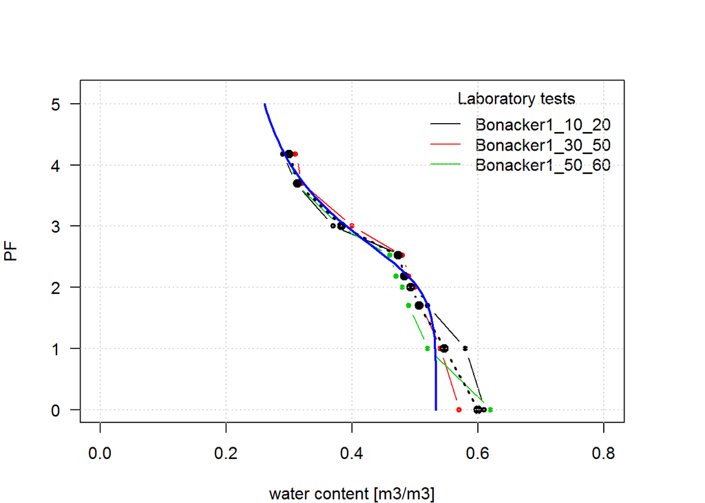

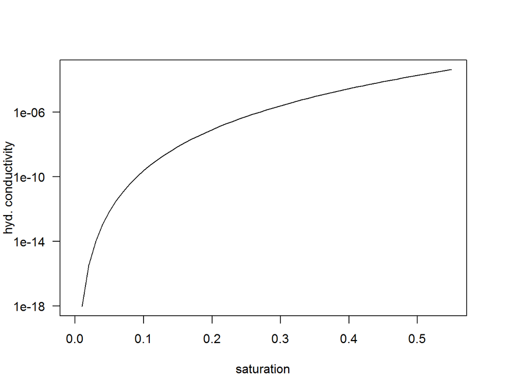

[output not shown]

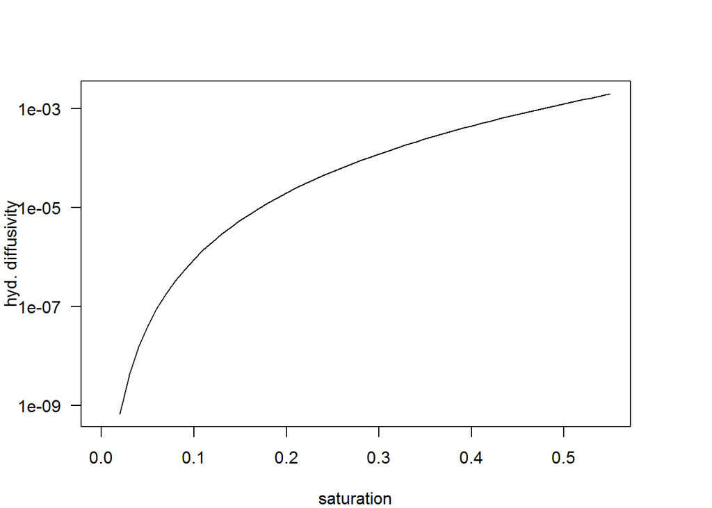

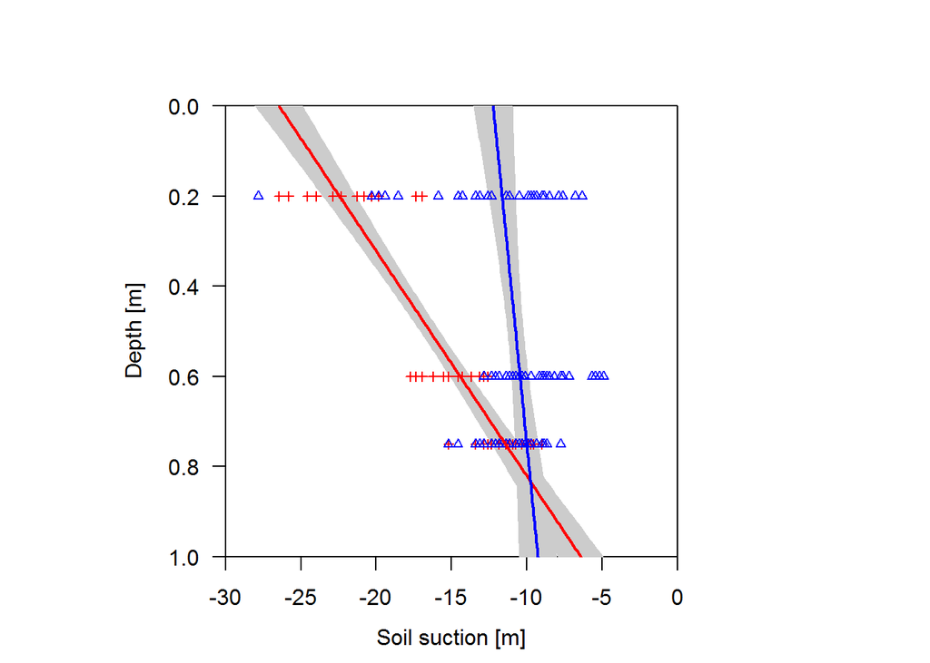

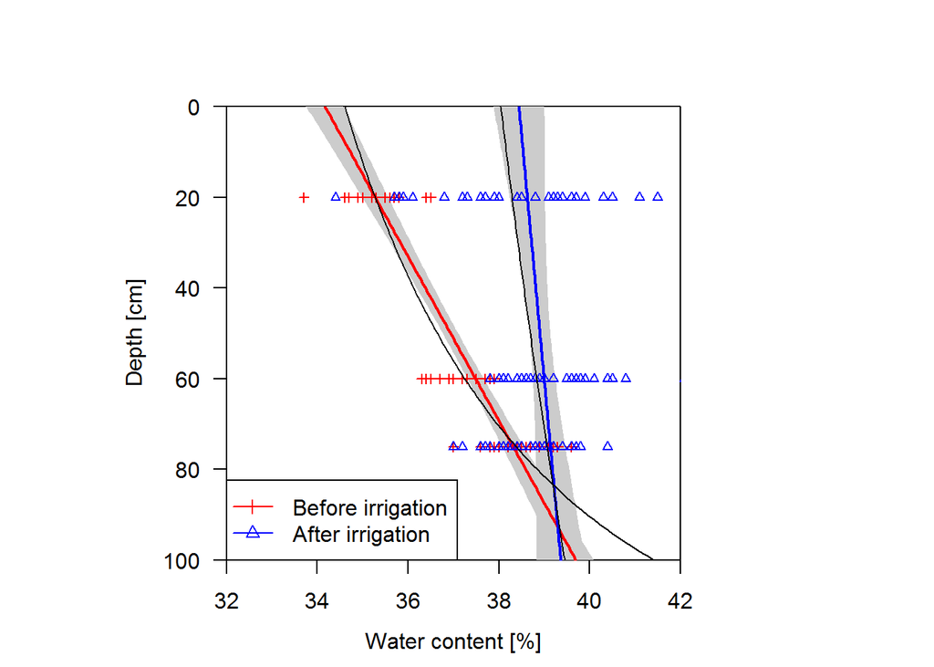

### Convert Resistivity Ratios to Water content

Initial state: linear inter-/extrapolation of recorded water content before irrigation (TDRs) with depth

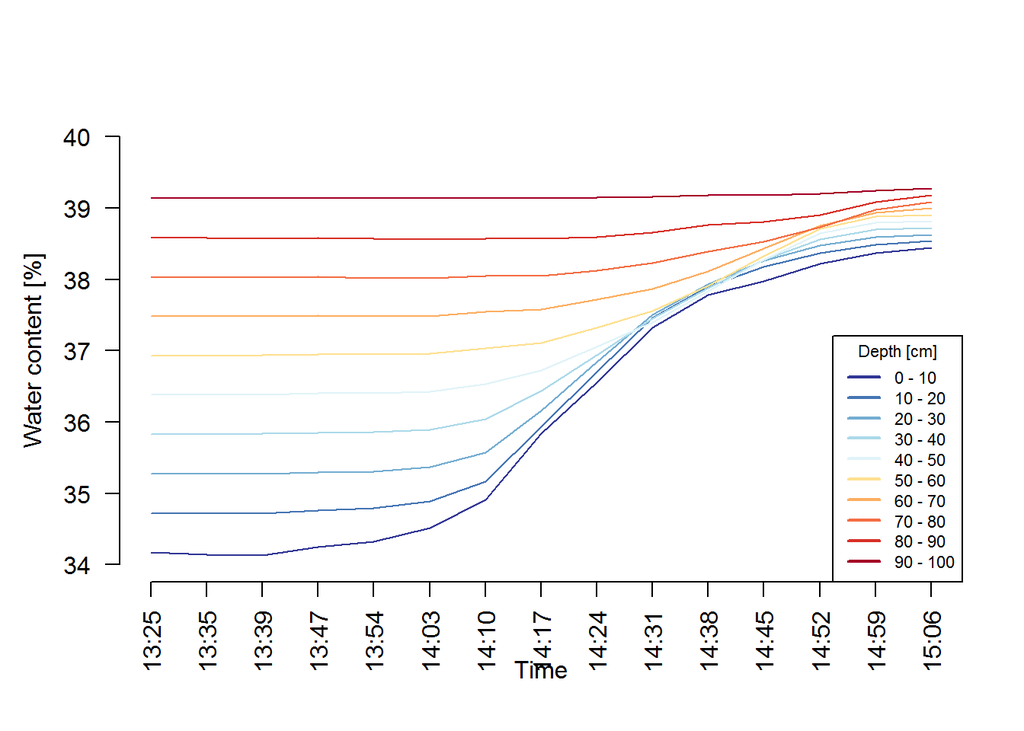

[figure not shown]

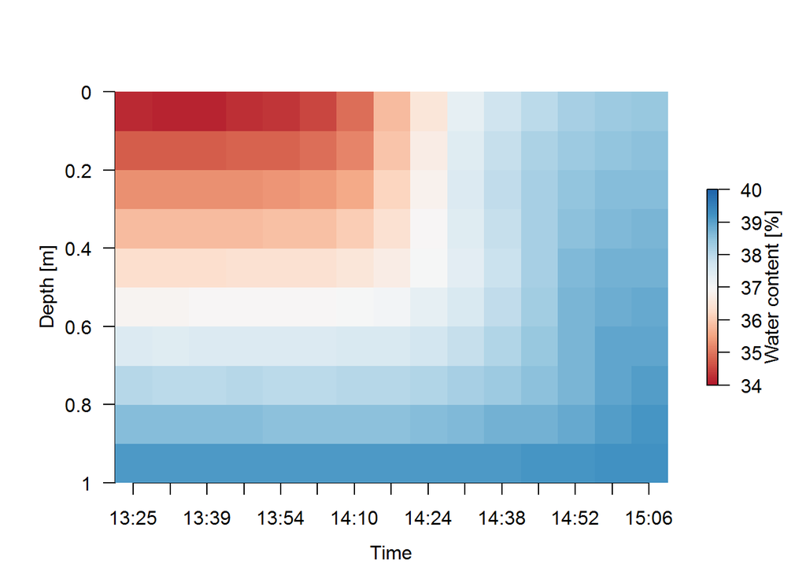

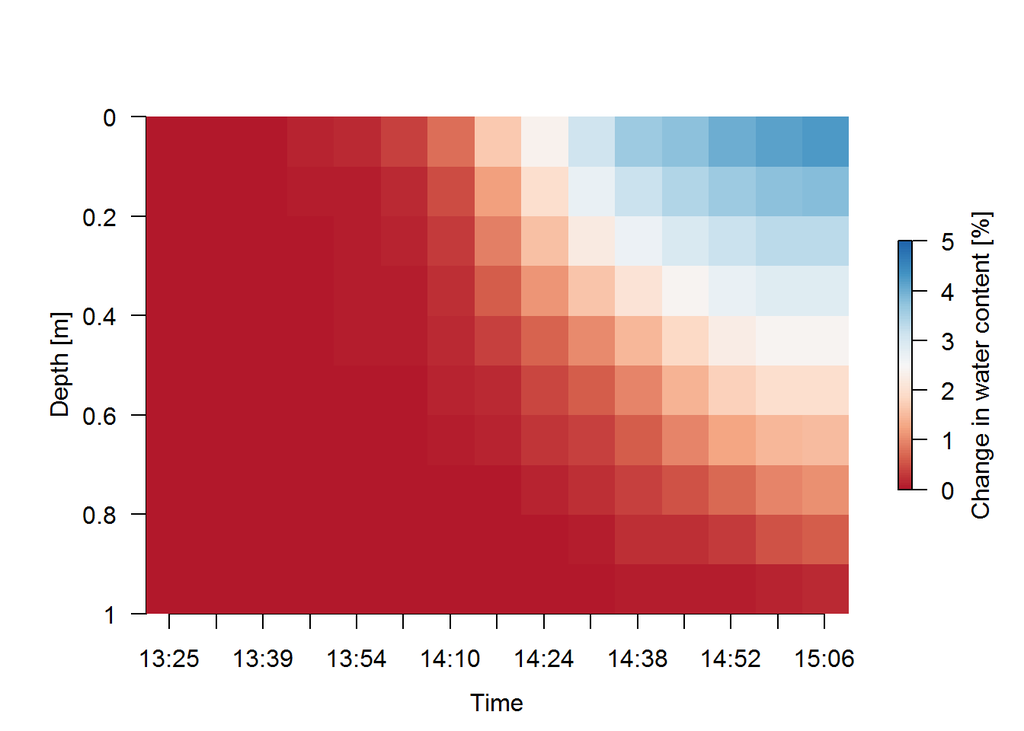

### Scale restistivity ratios to suction directly (skipping water content)

Initial state: linear inter-/extrapolation of converted soil suction before irrigation with depth

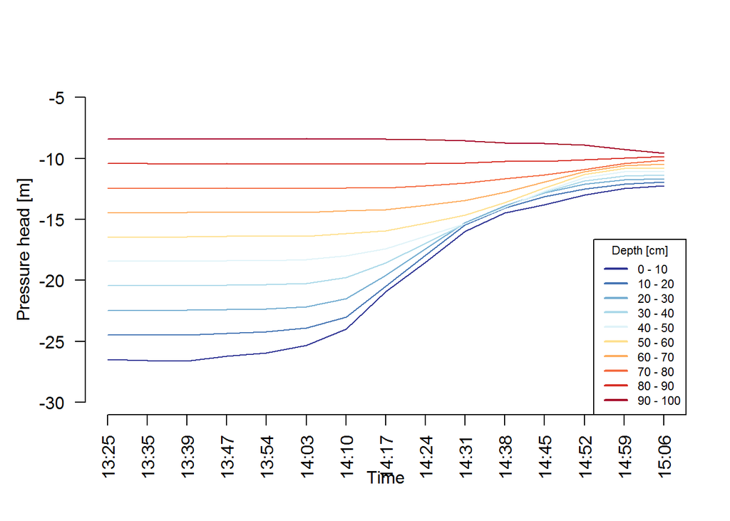

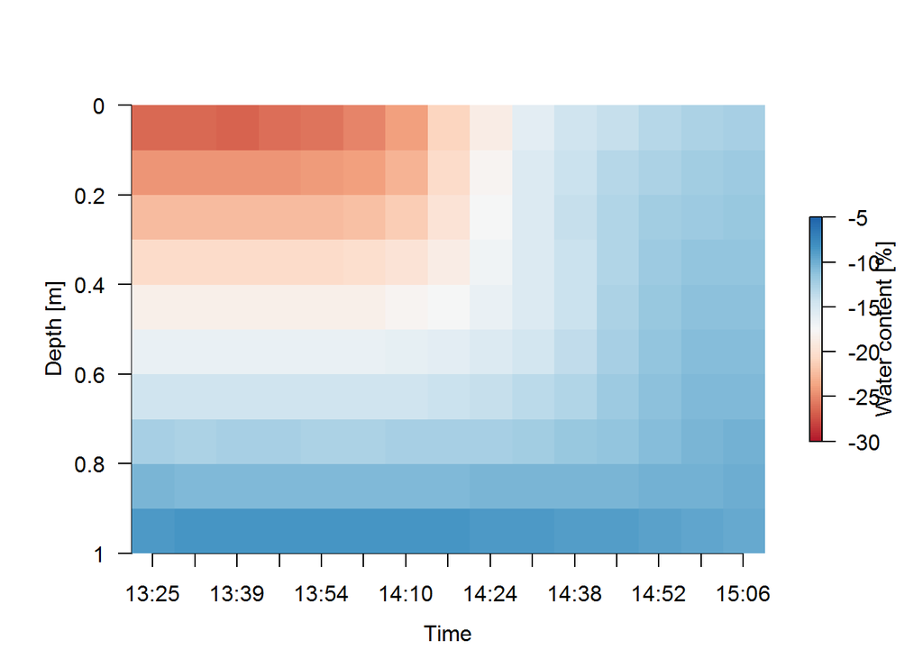

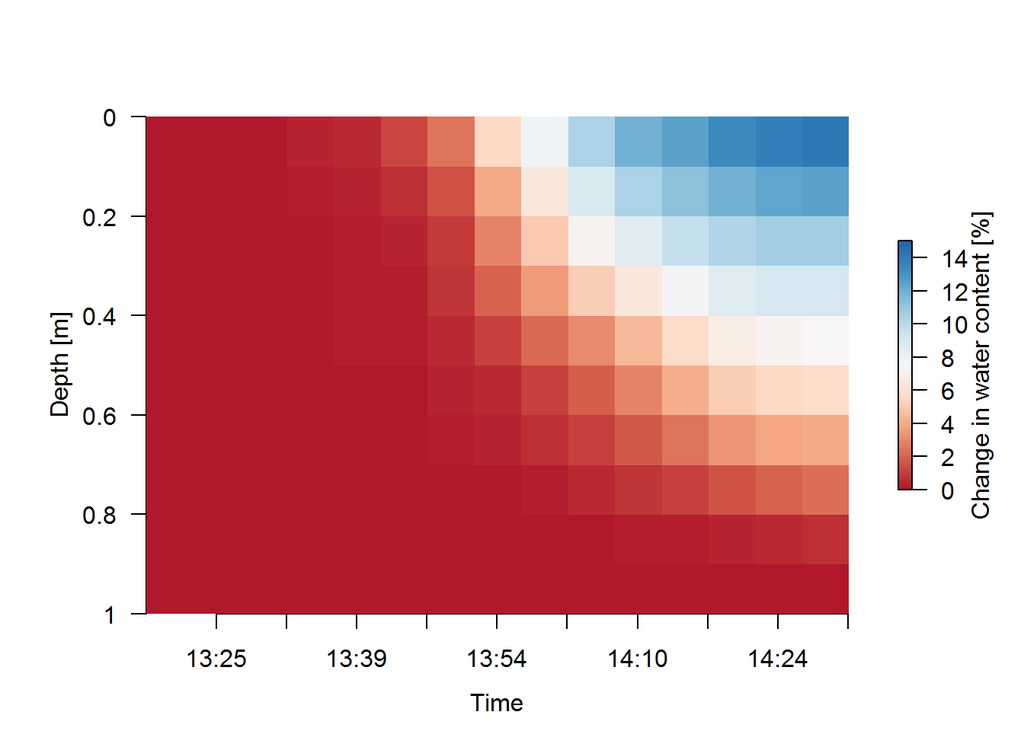

Calculate suction via fitted van Genuchten model

### Compare to model results

Tension-saturated initial conditions

```
## (Intercept)
##   -1.319821
```

```
##   depthm
## 20.04804
```

[output not shown]

[output cut: 37 more lines]

```
## [1] 0.9987242
```

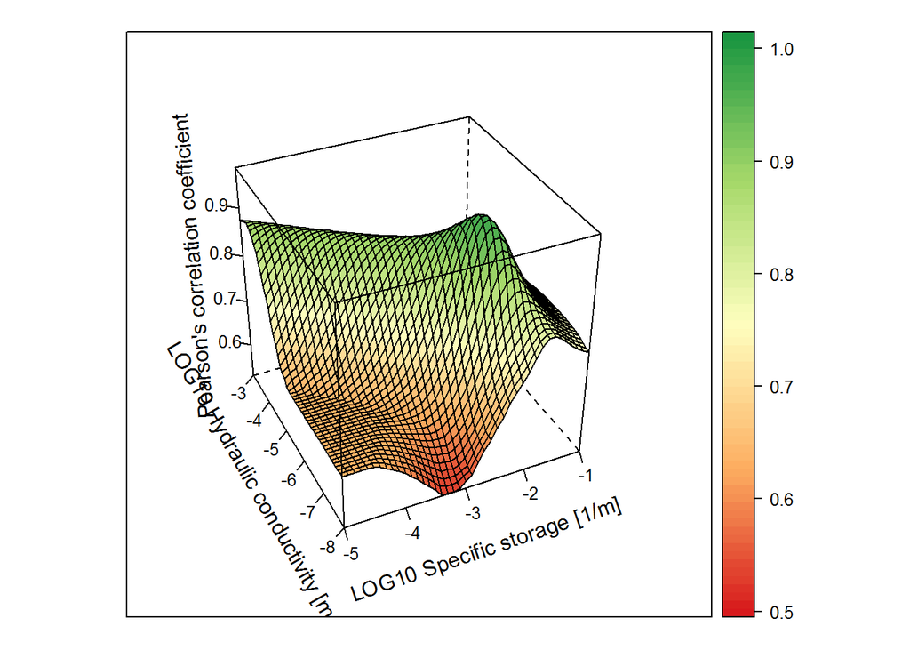

### Compare parameters

```
## [1] 0.09576741
```

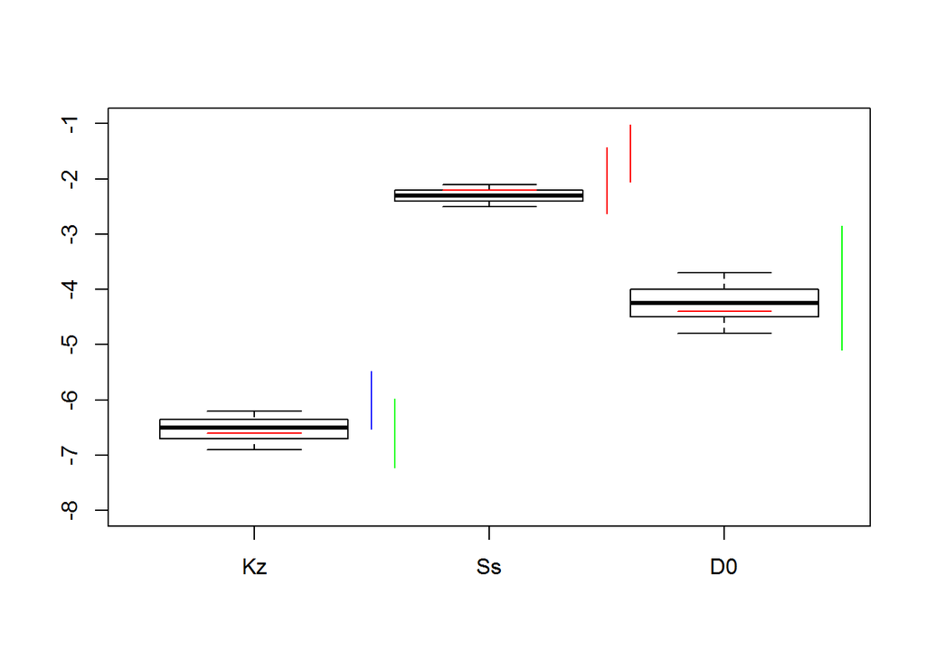

### plot best raster

Tension-saturated initial conditions

```
## [1] 0.9823559
```

```
##
##  Shapiro-Wilk normality test
##
## data:  log10(abs(data.r@data@values))
## W = 0.98283, p-value = 0.0583
```

```
##
##  Shapiro-Wilk normality test
##
## data:  log10(abs(Suctionrast@data@values))
## W = 0.96093, p-value = 0.0002984
```

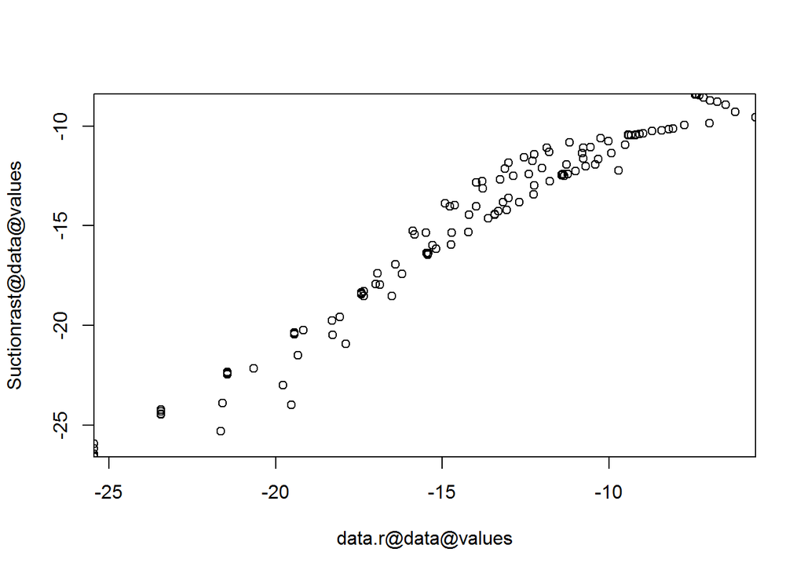

```
##
##  Paired t-test
##
## data:  data.r@data@values and Suctionrast@data@values
## t = 12.787, df = 149, p-value < 2.2e-16
## alternative hypothesis: true difference in means is not equal to 0
## 95 percent confidence interval:
##  0.8136426 1.1110718
## sample estimates:
## mean of the differences
##               0.9623572
```

```
## [1] -13.9154
```

```
## [1] -14.87775
```

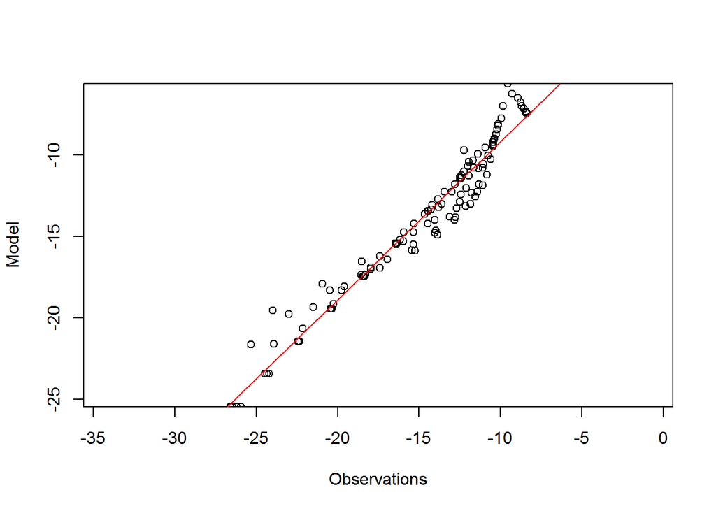

```
##
## Call:
## lm(formula = model ~ obs, data = datafit)
##
## Residuals:
##     Min      1Q  Median      3Q     Max
## -2.0842 -0.2887  0.0311  0.2543  3.2249
##
## Coefficients:
##             Estimate Std. Error t value Pr(>|t|)
## (Intercept)  0.54013    0.23821   2.267   0.0248 *
## obs          0.97162    0.01521  63.901   <2e-16 ***
## ---
## Signif. codes:  0 '***' 0.001 '**' 0.01 '*' 0.05 '.' 0.1 ' ' 1
##
## Residual standard error: 0.9142 on 148 degrees of freedom
## Multiple R-squared:  0.965,  Adjusted R-squared:  0.9648
## F-statistic:  4083 on 1 and 148 DF,  p-value: < 2.2e-16
```

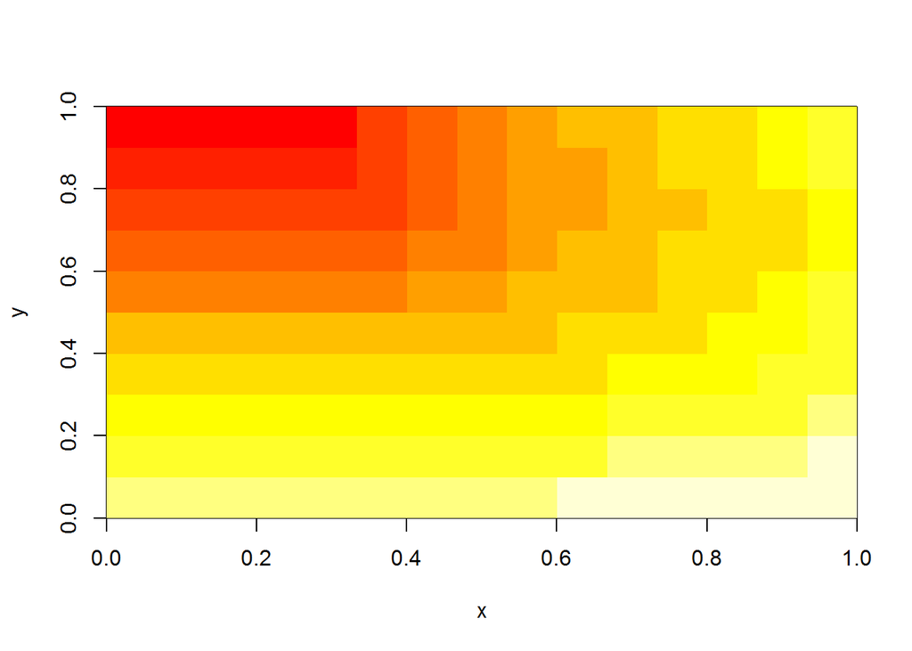

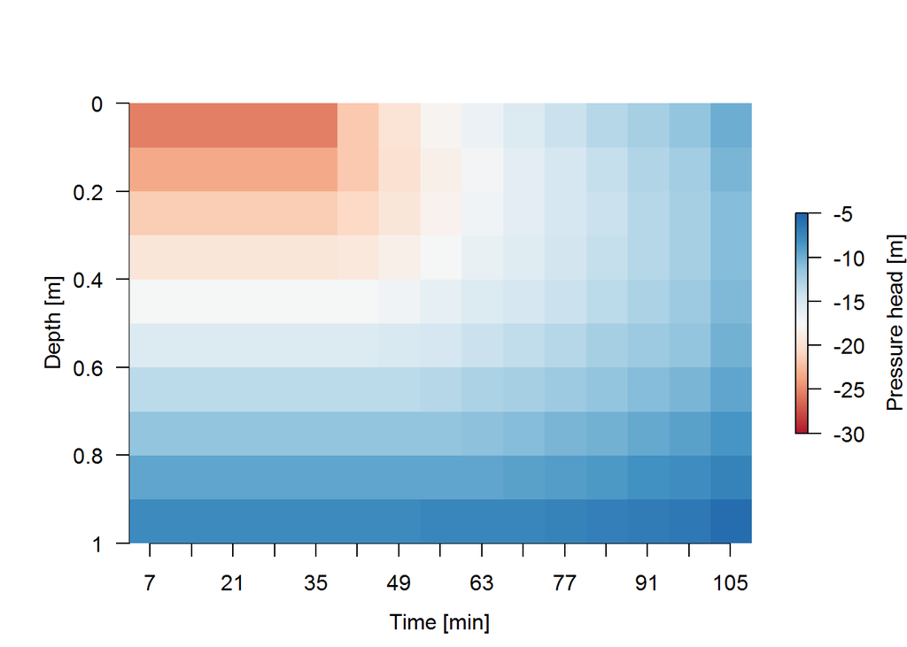

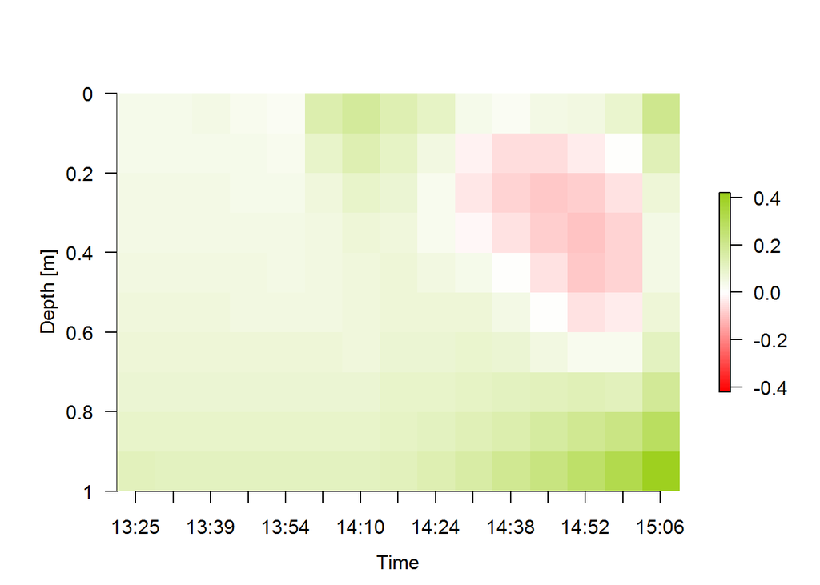

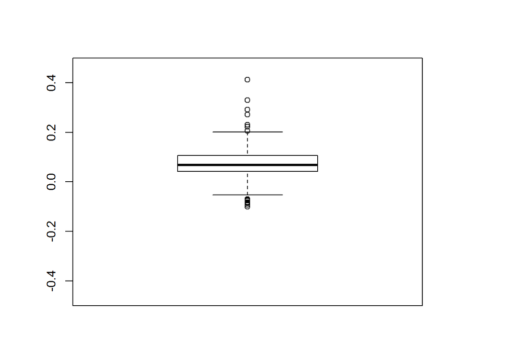

### Difference of last measurement to measurement next day

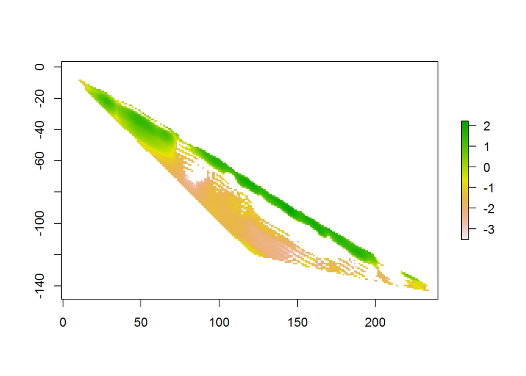

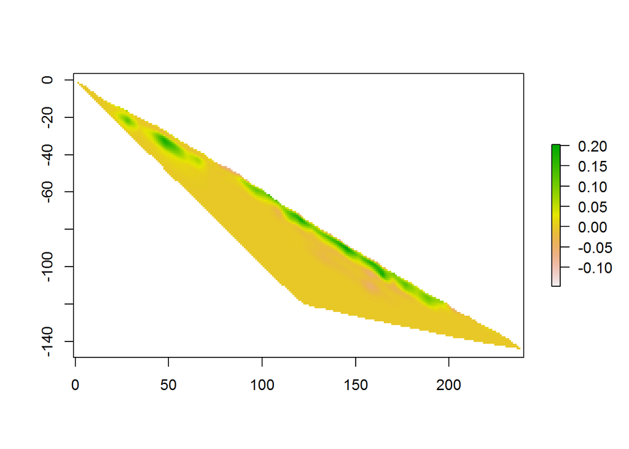